# Case Macro 4intelligence

Fernando Picchetti

2025-01-14

# Mercado de Combustíveis

## Análise de dados da ANP

### Carregando pacotes

Antes de qualquer coisa, é necessário carregar os pacotes do R que serão necessários

```r
library(readxl)
library(tidyr)
library(dplyr)
```

```r
library(urca)
library(ggplot2)
```

### Importando e formatando os dados

O primeiro passo para a análise de dados a seguir foi carregar os dados que estavam em formato de tabela na planilha disponibilizada. Após algumas manipulações, foi possível formatar os dados em 27 séries de tempo: uma para cada combustível em cada unidade geográfica analisada. A estratégia utilizada foi criar uma função que fizesse as manipulações comuns a todas as séries e aplicá-la nos diferentes conjuntos de dados.

```r
func <- function(sheet_name, range_start, range_end, meses, start) {
  data <- read_excel("vendas_distribuidoras_anp 1.xlsx",
                     sheet = sheet_name, range = paste0("C", range_start, ":X", range_end),
                     col_names = FALSE)
  data <- as_tibble(t(data), .name_repair = 'minimal')
  colnames(data) <- meses
  data <- data %>%
    pivot_longer(cols = everything(), names_to = "mes", values_to = "vendas_m3") %>%
    select(-mes)
  ts(data, start = start, frequency = 12)
}

meses <- c('1','2','3','4','5','6','7','8','9','10','11','12')
start <- c(2000,01)

df_diesel_ts <- func("diesel", 2, 13, meses, start)
go_diesel_ts <- func("diesel", 14, 25, meses, start)
ma_diesel_ts <- func("diesel", 26, 37, meses, start)
mt_diesel_ts <- func("diesel", 38, 49, meses, start)
mg_diesel_ts <- func("diesel", 50, 61, meses, start)
pa_diesel_ts <- func("diesel", 62, 73, meses, start)
sp_diesel_ts <- func("diesel", 74, 85, meses, start)
to_diesel_ts <- func("diesel", 86, 97, meses, start)
br_diesel_ts <- func("diesel", 98, 109, meses, start)

df_gasolina_ts <- func("gasolina", 2, 13, meses, start)
go_gasolina_ts <- func("gasolina", 14, 25, meses, start)
ma_gasolina_ts <- func("gasolina", 26, 37, meses, start)
mt_gasolina_ts <- func("gasolina", 38, 49, meses, start)
mg_gasolina_ts <- func("gasolina", 50, 61, meses, start)
pa_gasolina_ts <- func("gasolina", 62, 73, meses, start)
sp_gasolina_ts <- func("gasolina", 74, 85, meses, start)
to_gasolina_ts <- func("gasolina", 86, 97, meses, start)
br_gasolina_ts <- func("gasolina", 98, 109, meses, start)

df_etanol_ts <- func("etanol", 2, 13, meses, start)
go_etanol_ts <- func("etanol", 14, 25, meses, start)
ma_etanol_ts <- func("etanol", 26, 37, meses, start)
mt_etanol_ts <- func("etanol", 38, 49, meses, start)
mg_etanol_ts <- func("etanol", 50, 61, meses, start)
pa_etanol_ts <- func("etanol", 62, 73, meses, start)
sp_etanol_ts <- func("etanol", 74, 85, meses, start)
to_etanol_ts <- func("etanol", 86, 97, meses, start)
br_etanol_ts <- func("etanol", 98, 109, meses, start)
```

### Sazonalidade

Como o interesse está em analisar a sazonalidade da venda de combustíveis de forma geral e não de algum dos três em particular, criaram-se novas séries de tempo que agregam as vendas de diesel, etanol e gasolina para cada estado e para o Brasil. A agregação foi feita por meio de uma soma simples das séries individuais, já que todas estão na mesma unidade de medida (m³).

```r
df_combustíveis_ts <- df_etanol_ts + df_gasolina_ts + df_diesel_ts
go_combustíveis_ts <- go_etanol_ts + go_gasolina_ts + go_diesel_ts
ma_combustíveis_ts <- ma_etanol_ts + ma_gasolina_ts + ma_diesel_ts
mt_combustíveis_ts <- mt_etanol_ts + mt_gasolina_ts + mt_diesel_ts
mg_combustíveis_ts <- mg_etanol_ts + mg_gasolina_ts + mg_diesel_ts
pa_combustíveis_ts <- pa_etanol_ts + pa_gasolina_ts + pa_diesel_ts
sp_combustíveis_ts <- sp_etanol_ts + sp_gasolina_ts + sp_diesel_ts
to_combustíveis_ts <- to_etanol_ts + to_gasolina_ts + to_diesel_ts
br_combustíveis_ts <- br_etanol_ts + br_gasolina_ts + br_diesel_ts
```

O método utilizado para avaliar a sazonalidade das séries será a inspeção das Funções de autocorrelação (FAC). Contudo, para decidir se é mais adequado analisar a FAC das séries em nível ou em diferença, é necessário testar para a presença de raiz unitária. A seguir são apresentados testes de Dickey-Fuller Aumentados (ADF) para cada uma das séries. O procedimento adotado foi começar com o modelo mais completo (com tendência determinística e intercepto) e repetir o teste retirando os componentes que não se mostraram significantes a um nível de 5%.

#### Teste ADF com série do DF

```r
adf_test <- ur.df(na.omit(df_combustíveis_ts), type = "trend", lags = 10)
summary(adf_test)
```

```
##
## ###############################################
## # Augmented Dickey-Fuller Test Unit Root Test #
## ###############################################
##
## Test regression trend
##
##
## Call:
## lm(formula = z.diff ~ z.lag.1 + 1 + tt + z.diff.lag)
##
## Residuals:
##    Min     1Q Median     3Q    Max
## -36407  -4631    824   5866  17601
##
## Coefficients:
##                Estimate Std. Error t value Pr(>|t|)
## (Intercept)  5139.49654 6307.41242   0.815 0.416003
## z.lag.1        -0.03805    0.07296  -0.521 0.602526
## tt             -0.97217   19.05524  -0.051 0.959355
## z.diff.lag1    -0.50640    0.09228  -5.488 1.06e-07 ***
## z.diff.lag2    -0.42855    0.09484  -4.519 9.92e-06 ***
## z.diff.lag3    -0.23962    0.09125  -2.626 0.009214 **
## z.diff.lag4    -0.42094    0.08846  -4.758 3.44e-06 ***
## z.diff.lag5    -0.22910    0.08757  -2.616 0.009476 **
## z.diff.lag6    -0.34342    0.08633  -3.978 9.29e-05 ***
## z.diff.lag7    -0.23368    0.08284  -2.821 0.005203 **
## z.diff.lag8    -0.39040    0.08143  -4.794 2.92e-06 ***
## z.diff.lag9    -0.22929    0.07764  -2.953 0.003469 **
## z.diff.lag10   -0.24527    0.06717  -3.651 0.000322 ***
## ---
## Signif. codes:  0 '***' 0.001 '**' 0.01 '*' 0.05 '.' 0.1 ' ' 1
##
## Residual standard error: 8414 on 232 degrees of freedom
## Multiple R-squared:  0.3407, Adjusted R-squared:  0.3066
## F-statistic: 9.989 on 12 and 232 DF,  p-value: 1.031e-15
##
##
## Value of test-statistic is: -0.5215 1.0197 0.9998
##
## Critical values for test statistics:
##       1pct  5pct 10pct
## tau3 -3.98 -3.42 -3.13
## phi2  6.15  4.71  4.05
## phi3  8.34  6.30  5.36
```

O teste não rejeita a nula de raiz unitária, mas o intercepto e a tendência determinística não são estatisticamente significantes. Logo, segue o teste sem componentes determinísticos:

```r
adf_test <- ur.df(na.omit(df_combustíveis_ts), type = "none", lags = 10)
summary(adf_test)
```

```
##
## ###############################################
## # Augmented Dickey-Fuller Test Unit Root Test #
## ###############################################
##
## Test regression none
##
##
## Call:
## lm(formula = z.diff ~ z.lag.1 - 1 + z.diff.lag)
##
## Residuals:
##    Min     1Q Median     3Q    Max
## -37099  -4425   1034   5827  17166
##
## Coefficients:
##               Estimate Std. Error t value Pr(>|t|)
## z.lag.1       0.003641   0.004575   0.796 0.426974
## z.diff.lag1  -0.538535   0.063773  -8.445 3.24e-15 ***
## z.diff.lag2  -0.455045   0.071269  -6.385 9.13e-10 ***
## z.diff.lag3  -0.262251   0.073295  -3.578 0.000421 ***
## z.diff.lag4  -0.440701   0.074269  -5.934 1.06e-08 ***
## z.diff.lag5  -0.244759   0.076851  -3.185 0.001645 **
## z.diff.lag6  -0.356227   0.076993  -4.627 6.15e-06 ***
## z.diff.lag7  -0.242970   0.075645  -3.212 0.001503 **
## z.diff.lag8  -0.396928   0.075381  -5.266 3.16e-07 ***
## z.diff.lag9  -0.232129   0.073650  -3.152 0.001835 **
## z.diff.lag10 -0.245564   0.064967  -3.780 0.000199 ***
## ---
## Signif. codes:  0 '***' 0.001 '**' 0.01 '*' 0.05 '.' 0.1 ' ' 1
##
## Residual standard error: 8422 on 234 degrees of freedom
## Multiple R-squared:  0.3338, Adjusted R-squared:  0.3025
## F-statistic: 10.66 on 11 and 234 DF,  p-value: 7.62e-16
##
##
## Value of test-statistic is: 0.7958
##
## Critical values for test statistics:
##       1pct  5pct 10pct
## tau1 -2.58 -1.95 -1.62
```

O teste não rejeita a nula de raiz unitária, logo o correto será trabalhar com a série em primeira diferença.

#### Teste ADF com série de GO

```r
adf_test <- ur.df(na.omit(go_combustíveis_ts), type = "trend", lags = 10)
summary(adf_test)
```

```
##
## ###############################################
## # Augmented Dickey-Fuller Test Unit Root Test #
## ###############################################
##
## Test regression trend
##
##
## Call:
## lm(formula = z.diff ~ z.lag.1 + 1 + tt + z.diff.lag)
##
## Residuals:
##    Min     1Q Median     3Q    Max
## -80380 -12823    405  13338  76635
##
## Coefficients:
##                Estimate Std. Error t value Pr(>|t|)
## (Intercept)   1.373e+04  7.243e+03   1.896 0.059214 .
## z.lag.1      -6.254e-02  4.698e-02  -1.331 0.184470
## tt            9.467e+01  7.259e+01   1.304 0.193450
## z.diff.lag1  -4.061e-01  7.503e-02  -5.412 1.55e-07 ***
## z.diff.lag2  -3.280e-01  7.736e-02  -4.240 3.22e-05 ***
## z.diff.lag3  -1.542e-01  7.466e-02  -2.066 0.039927 *
## z.diff.lag4  -3.192e-01  7.234e-02  -4.413 1.56e-05 ***
## z.diff.lag5  -1.814e-01  6.806e-02  -2.665 0.008242 **
## z.diff.lag6  -4.424e-01  6.745e-02  -6.559 3.50e-10 ***
## z.diff.lag7  -2.762e-01  7.013e-02  -3.938 0.000109 ***
## z.diff.lag8  -4.012e-01  7.127e-02  -5.629 5.21e-08 ***
## z.diff.lag9  -2.469e-01  7.112e-02  -3.472 0.000616 ***
## z.diff.lag10 -2.409e-01  6.603e-02  -3.649 0.000325 ***
## ---
## Signif. codes:  0 '***' 0.001 '**' 0.01 '*' 0.05 '.' 0.1 ' ' 1
##
## Residual standard error: 22720 on 232 degrees of freedom
## Multiple R-squared:  0.3321, Adjusted R-squared:  0.2976
## F-statistic: 9.613 on 12 and 232 DF,  p-value: 4.065e-15
##
##
## Value of test-statistic is: -1.3311 4.5772 0.8906
##
## Critical values for test statistics:
##       1pct  5pct 10pct
## tau3 -3.98 -3.42 -3.13
## phi2  6.15  4.71  4.05
## phi3  8.34  6.30  5.36
```

O teste não rejeita a nula de raiz unitária, mas o intercepto e a tendência determinística não são estatisticamente significantes. Logo, segue o teste sem componentes determinísticos:

```r
adf_test <- ur.df(na.omit(go_combustíveis_ts), type = "none", lags = 10)
summary(adf_test)
```

```
##
## ###############################################
## # Augmented Dickey-Fuller Test Unit Root Test #
## ###############################################
##
## Test regression none
##
##
## Call:
## lm(formula = z.diff ~ z.lag.1 - 1 + z.diff.lag)
##
## Residuals:
##    Min     1Q Median     3Q    Max
## -83826 -11070   2111  14509  75808
##
## Coefficients:
##               Estimate Std. Error t value Pr(>|t|)
## z.lag.1       0.013727   0.004336   3.166 0.001750 **
## z.diff.lag1  -0.466285   0.064331  -7.248 6.10e-12 ***
## z.diff.lag2  -0.380661   0.069149  -5.505 9.68e-08 ***
## z.diff.lag3  -0.200131   0.068147  -2.937 0.003648 **
## z.diff.lag4  -0.361211   0.066959  -5.395 1.68e-07 ***
## z.diff.lag5  -0.216716   0.064197  -3.376 0.000862 ***
## z.diff.lag6  -0.473769   0.064502  -7.345 3.40e-12 ***
## z.diff.lag7  -0.299658   0.068392  -4.381 1.78e-05 ***
## z.diff.lag8  -0.419673   0.070056  -5.991 7.83e-09 ***
## z.diff.lag9  -0.258085   0.070609  -3.655 0.000317 ***
## z.diff.lag10 -0.247087   0.065855  -3.752 0.000221 ***
## ---
## Signif. codes:  0 '***' 0.001 '**' 0.01 '*' 0.05 '.' 0.1 ' ' 1
##
## Residual standard error: 22800 on 234 degrees of freedom
## Multiple R-squared:  0.3228, Adjusted R-squared:  0.291
## F-statistic: 10.14 on 11 and 234 DF,  p-value: 4.505e-15
##
##
## Value of test-statistic is: 3.1661
##
## Critical values for test statistics:
##       1pct  5pct 10pct
## tau1 -2.58 -1.95 -1.62
```

O teste não rejeita a nula de raiz unitária, logo o correto será trabalhar com a série em primeira diferença.

#### Teste ADF com série do MA

```r
adf_test <- ur.df(na.omit(ma_combustíveis_ts), type = "trend", lags = 10)
summary(adf_test)
```

```
##
## ###############################################
## # Augmented Dickey-Fuller Test Unit Root Test #
## ###############################################
##
## Test regression trend
##
##
## Call:
## lm(formula = z.diff ~ z.lag.1 + 1 + tt + z.diff.lag)
##
## Residuals:
##    Min     1Q Median     3Q    Max
## -34001  -4511    333   5592  21276
##
## Coefficients:
##                Estimate Std. Error t value Pr(>|t|)
## (Intercept)   5.649e+03  2.455e+03   2.301  0.02229 *
## z.lag.1      -8.120e-02  4.779e-02  -1.699  0.09062 .
## tt            5.857e+01  3.294e+01   1.778  0.07670 .
## z.diff.lag1  -2.924e-01  7.290e-02  -4.012 8.14e-05 ***
## z.diff.lag2  -4.105e-01  7.595e-02  -5.405 1.61e-07 ***
## z.diff.lag3   4.225e-02  7.298e-02   0.579  0.56323
## z.diff.lag4  -3.501e-01  7.034e-02  -4.977 1.26e-06 ***
## z.diff.lag5  -1.671e-01  5.896e-02  -2.835  0.00499 **
## z.diff.lag6  -6.402e-01  5.840e-02 -10.962  < 2e-16 ***
## z.diff.lag7  -2.814e-01  6.727e-02  -4.184 4.07e-05 ***
## z.diff.lag8  -4.786e-01  7.003e-02  -6.835 7.18e-11 ***
## z.diff.lag9  -6.153e-03  6.928e-02  -0.089  0.92931
## z.diff.lag10 -3.441e-01  6.465e-02  -5.323 2.41e-07 ***
## ---
## Signif. codes:  0 '***' 0.001 '**' 0.01 '*' 0.05 '.' 0.1 ' ' 1
##
## Residual standard error: 7938 on 232 degrees of freedom
## Multiple R-squared:  0.5211, Adjusted R-squared:  0.4963
## F-statistic: 21.04 on 12 and 232 DF,  p-value: < 2.2e-16
##
##
## Value of test-statistic is: -1.6992 7.5376 1.5944
##
## Critical values for test statistics:
##       1pct  5pct 10pct
## tau3 -3.98 -3.42 -3.13
## phi2  6.15  4.71  4.05
## phi3  8.34  6.30  5.36
```

O teste não rejeita a nula de raiz unitária, mas a tendência determinística não é estatisticamente significante. Logo, segue o teste apenas com *drift*:

```r
adf_test <- ur.df(na.omit(ma_combustíveis_ts), type = "drift", lags = 10)
summary(adf_test)
```

```
##
## ###############################################
## # Augmented Dickey-Fuller Test Unit Root Test #
## ###############################################
##
## Test regression drift
##
##
## Call:
## lm(formula = z.diff ~ z.lag.1 + 1 + z.diff.lag)
##
## Residuals:
##    Min     1Q Median     3Q    Max
## -33986  -4511     65   5052  23346
##
## Coefficients:
##                Estimate Std. Error t value Pr(>|t|)
## (Intercept)   2.201e+03  1.513e+03   1.455 0.147023
## z.lag.1       1.721e-03  1.047e-02   0.164 0.869630
## z.diff.lag1  -3.601e-01  6.246e-02  -5.766 2.57e-08 ***
## z.diff.lag2  -4.745e-01  6.720e-02  -7.061 1.89e-11 ***
## z.diff.lag3  -1.127e-02  6.679e-02  -0.169 0.866111
## z.diff.lag4  -4.011e-01  6.452e-02  -6.216 2.33e-09 ***
## z.diff.lag5  -2.082e-01  5.451e-02  -3.819 0.000172 ***
## z.diff.lag6  -6.774e-01  5.477e-02 -12.370  < 2e-16 ***
## z.diff.lag7  -3.083e-01  6.586e-02  -4.681 4.84e-06 ***
## z.diff.lag8  -5.020e-01  6.910e-02  -7.265 5.57e-12 ***
## z.diff.lag9  -1.943e-02  6.919e-02  -0.281 0.779078
## z.diff.lag10 -3.556e-01  6.462e-02  -5.502 9.86e-08 ***
## ---
## Signif. codes:  0 '***' 0.001 '**' 0.01 '*' 0.05 '.' 0.1 ' ' 1
##
## Residual standard error: 7975 on 233 degrees of freedom
## Multiple R-squared:  0.5146, Adjusted R-squared:  0.4916
## F-statistic: 22.45 on 11 and 233 DF,  p-value: < 2.2e-16
##
##
## Value of test-statistic is: 0.1643 9.6363
##
## Critical values for test statistics:
##       1pct  5pct 10pct
## tau2 -3.44 -2.87 -2.57
## phi1  6.47  4.61  3.79
```

O teste não rejeita a nula de raiz unitária, mas o intercepto deixou de ser significante. Assim, repete-se o teste sem componentes determinísticos:

```r
adf_test <- ur.df(na.omit(ma_combustíveis_ts), type = "none", lags = 10)
summary(adf_test)
```

```
##
## ###############################################
## # Augmented Dickey-Fuller Test Unit Root Test #
## ###############################################
##
## Test regression none
##
##
## Call:
## lm(formula = z.diff ~ z.lag.1 - 1 + z.diff.lag)
##
## Residuals:
##    Min     1Q Median     3Q    Max
## -34602  -4141    687   5634  23143
##
## Coefficients:
##               Estimate Std. Error t value Pr(>|t|)
## z.lag.1       0.015899   0.003848   4.132 5.01e-05 ***
## z.diff.lag1  -0.367048   0.062423  -5.880 1.41e-08 ***
## z.diff.lag2  -0.477339   0.067328  -7.090 1.58e-11 ***
## z.diff.lag3  -0.013588   0.066934  -0.203  0.83931
## z.diff.lag4  -0.405510   0.064603  -6.277 1.66e-09 ***
## z.diff.lag5  -0.213352   0.054524  -3.913  0.00012 ***
## z.diff.lag6  -0.681812   0.054814 -12.439  < 2e-16 ***
## z.diff.lag7  -0.308101   0.066015  -4.667 5.14e-06 ***
## z.diff.lag8  -0.498547   0.069222  -7.202 8.05e-12 ***
## z.diff.lag9  -0.014610   0.069278  -0.211  0.83315
## z.diff.lag10 -0.352283   0.064737  -5.442 1.33e-07 ***
## ---
## Signif. codes:  0 '***' 0.001 '**' 0.01 '*' 0.05 '.' 0.1 ' ' 1
##
## Residual standard error: 7994 on 234 degrees of freedom
## Multiple R-squared:  0.5111, Adjusted R-squared:  0.4881
## F-statistic: 22.23 on 11 and 234 DF,  p-value: < 2.2e-16
##
##
## Value of test-statistic is: 4.1321
##
## Critical values for test statistics:
##       1pct  5pct 10pct
## tau1 -2.58 -1.95 -1.62
```

O teste não rejeita a nula de raiz unitária, logo o correto será trabalhar com a série em primeira diferença.

#### Teste ADF com série do MT

```r
adf_test <- ur.df(na.omit(mt_combustíveis_ts), type = "trend", lags = 10)
summary(adf_test)
```

```
##
## ###############################################
## # Augmented Dickey-Fuller Test Unit Root Test #
## ###############################################
##
## Test regression trend
##
##
## Call:
## lm(formula = z.diff ~ z.lag.1 + 1 + tt + z.diff.lag)
##
## Residuals:
##    Min     1Q Median     3Q    Max
## -65547 -12238   -499  13170  64095
##
## Coefficients:
##                Estimate Std. Error t value Pr(>|t|)
## (Intercept)   1.586e+04  8.426e+03   1.882  0.06103 .
## z.lag.1      -1.207e-01  6.612e-02  -1.826  0.06918 .
## tt            1.476e+02  6.961e+01   2.121  0.03499 *
## z.diff.lag1  -2.269e-01  7.887e-02  -2.877  0.00439 **
## z.diff.lag2  -5.028e-01  7.646e-02  -6.575 3.18e-10 ***
## z.diff.lag3  -3.926e-01  7.884e-02  -4.980 1.24e-06 ***
## z.diff.lag4  -4.389e-01  8.046e-02  -5.455 1.25e-07 ***
## z.diff.lag5  -1.486e-01  7.685e-02  -1.933  0.05440 .
## z.diff.lag6  -4.825e-01  7.654e-02  -6.303 1.45e-09 ***
## z.diff.lag7  -2.138e-01  7.503e-02  -2.850  0.00477 **
## z.diff.lag8  -2.941e-01  6.926e-02  -4.246 3.15e-05 ***
## z.diff.lag9  -2.718e-01  6.008e-02  -4.524 9.68e-06 ***
## z.diff.lag10 -5.199e-01  5.852e-02  -8.883  < 2e-16 ***
## ---
## Signif. codes:  0 '***' 0.001 '**' 0.01 '*' 0.05 '.' 0.1 ' ' 1
##
## Residual standard error: 21400 on 232 degrees of freedom
## Multiple R-squared:  0.5488, Adjusted R-squared:  0.5255
## F-statistic: 23.52 on 12 and 232 DF,  p-value: < 2.2e-16
##
##
## Value of test-statistic is: -1.8257 5.4672 2.5328
##
## Critical values for test statistics:
##       1pct  5pct 10pct
## tau3 -3.98 -3.42 -3.13
## phi2  6.15  4.71  4.05
## phi3  8.34  6.30  5.36
```

O teste não rejeita a nula de raiz unitária e a tendência é estatisticamente significante. Então, o correto será trabalhar com a série em primeira diferença.

#### Teste ADF com série de MG

```r
adf_test <- ur.df(na.omit(mg_combustíveis_ts), type = "trend", lags = 10)
summary(adf_test)
```

```
##
## ###############################################
## # Augmented Dickey-Fuller Test Unit Root Test #
## ###############################################
##
## Test regression trend
##
##
## Call:
## lm(formula = z.diff ~ z.lag.1 + 1 + tt + z.diff.lag)
##
## Residuals:
##     Min      1Q  Median      3Q     Max
## -186839  -29126    2515   29958  109546
##
## Coefficients:
##                Estimate Std. Error t value Pr(>|t|)
## (Intercept)   4.586e+04  3.147e+04   1.457 0.146331
## z.lag.1      -6.336e-02  5.864e-02  -1.080 0.281079
## tt            1.513e+02  1.622e+02   0.933 0.351811
## z.diff.lag1  -6.291e-01  8.314e-02  -7.567 8.95e-13 ***
## z.diff.lag2  -4.448e-01  9.074e-02  -4.901 1.79e-06 ***
## z.diff.lag3  -9.469e-02  8.578e-02  -1.104 0.270788
## z.diff.lag4  -2.799e-01  7.896e-02  -3.546 0.000474 ***
## z.diff.lag5  -2.656e-01  7.093e-02  -3.745 0.000228 ***
## z.diff.lag6  -5.189e-01  6.948e-02  -7.469 1.63e-12 ***
## z.diff.lag7  -4.410e-01  7.403e-02  -5.957 9.46e-09 ***
## z.diff.lag8  -5.400e-01  7.877e-02  -6.855 6.39e-11 ***
## z.diff.lag9  -2.514e-01  7.919e-02  -3.175 0.001703 **
## z.diff.lag10 -1.711e-01  6.633e-02  -2.579 0.010520 *
## ---
## Signif. codes:  0 '***' 0.001 '**' 0.01 '*' 0.05 '.' 0.1 ' ' 1
##
## Residual standard error: 48860 on 232 degrees of freedom
## Multiple R-squared:  0.4708, Adjusted R-squared:  0.4435
## F-statistic:  17.2 on 12 and 232 DF,  p-value: < 2.2e-16
##
##
## Value of test-statistic is: -1.0804 3.7856 0.6602
##
## Critical values for test statistics:
##       1pct  5pct 10pct
## tau3 -3.98 -3.42 -3.13
## phi2  6.15  4.71  4.05
## phi3  8.34  6.30  5.36
```

O teste não rejeita a nula de raiz unitária, mas o intercepto e a tendência determinística não são estatisticamente significantes. Logo, segue o teste sem componentes determinísticos:

```r
adf_test <- ur.df(na.omit(mg_combustíveis_ts), type = "none", lags = 10)
summary(adf_test)
```

```
##
## ###############################################
## # Augmented Dickey-Fuller Test Unit Root Test #
## ###############################################
##
## Test regression none
##
##
## Call:
## lm(formula = z.diff ~ z.lag.1 - 1 + z.diff.lag)
##
## Residuals:
##     Min      1Q  Median      3Q     Max
## -187521  -27453    4280   30621  110566
##
## Coefficients:
##               Estimate Std. Error t value Pr(>|t|)
## z.lag.1       0.010609   0.003622   2.929 0.003734 **
## z.diff.lag1  -0.690765   0.065068 -10.616  < 2e-16 ***
## z.diff.lag2  -0.497686   0.077402  -6.430 7.11e-10 ***
## z.diff.lag3  -0.139864   0.075557  -1.851 0.065413 .
## z.diff.lag4  -0.321804   0.070110  -4.590 7.23e-06 ***
## z.diff.lag5  -0.302118   0.064014  -4.720 4.07e-06 ***
## z.diff.lag6  -0.550861   0.064135  -8.589 1.25e-15 ***
## z.diff.lag7  -0.465458   0.070673  -6.586 2.95e-10 ***
## z.diff.lag8  -0.558461   0.076286  -7.321 3.94e-12 ***
## z.diff.lag9  -0.261796   0.077977  -3.357 0.000918 ***
## z.diff.lag10 -0.176249   0.065809  -2.678 0.007926 **
## ---
## Signif. codes:  0 '***' 0.001 '**' 0.01 '*' 0.05 '.' 0.1 ' ' 1
##
## Residual standard error: 48940 on 234 degrees of freedom
## Multiple R-squared:  0.465,  Adjusted R-squared:  0.4398
## F-statistic: 18.49 on 11 and 234 DF,  p-value: < 2.2e-16
##
##
## Value of test-statistic is: 2.9292
##
## Critical values for test statistics:
##       1pct  5pct 10pct
## tau1 -2.58 -1.95 -1.62
```

O teste não rejeita a nula de raiz unitária, logo o correto será trabalhar com a série em primeira diferença.

#### Teste ADF com série do PA

```r
adf_test <- ur.df(na.omit(pa_combustíveis_ts), type = "trend", lags = 10)
summary(adf_test)
```

```
##
## ###############################################
## # Augmented Dickey-Fuller Test Unit Root Test #
## ###############################################
##
## Test regression trend
##
##
## Call:
## lm(formula = z.diff ~ z.lag.1 + 1 + tt + z.diff.lag)
##
## Residuals:
##    Min     1Q Median     3Q    Max
## -37532  -5523    213   6116  33729
##
## Coefficients:
##                Estimate Std. Error t value Pr(>|t|)
## (Intercept)  9133.66562 4577.43080   1.995  0.04717 *
## z.lag.1        -0.08377    0.04979  -1.683  0.09380 .
## tt             94.81981   48.09937   1.971  0.04987 *
## z.diff.lag1    -0.39122    0.07500  -5.216 4.05e-07 ***
## z.diff.lag2    -0.35876    0.07950  -4.513 1.02e-05 ***
## z.diff.lag3     0.03088    0.07487   0.412  0.68037
## z.diff.lag4    -0.36378    0.07055  -5.156 5.39e-07 ***
## z.diff.lag5    -0.20196    0.06150  -3.284  0.00118 **
## z.diff.lag6    -0.60517    0.06054  -9.996  < 2e-16 ***
## z.diff.lag7    -0.34459    0.06727  -5.123 6.33e-07 ***
## z.diff.lag8    -0.48464    0.07097  -6.829 7.42e-11 ***
## z.diff.lag9    -0.06770    0.07193  -0.941  0.34758
## z.diff.lag10   -0.28661    0.06527  -4.391 1.71e-05 ***
## ---
## Signif. codes:  0 '***' 0.001 '**' 0.01 '*' 0.05 '.' 0.1 ' ' 1
##
## Residual standard error: 11480 on 232 degrees of freedom
## Multiple R-squared:  0.5404, Adjusted R-squared:  0.5167
## F-statistic: 22.73 on 12 and 232 DF,  p-value: < 2.2e-16
##
##
## Value of test-statistic is: -1.6826 9.5999 2.561
##
## Critical values for test statistics:
##       1pct  5pct 10pct
## tau3 -3.98 -3.42 -3.13
## phi2  6.15  4.71  4.05
## phi3  8.34  6.30  5.36
```

```r
adf_test <- ur.df(na.omit(sp_combustíveis_ts), type = "trend", lags = 10)
summary(adf_test)
```

```
##
## ###############################################
## # Augmented Dickey-Fuller Test Unit Root Test #
## ###############################################
##
## Test regression trend
##
##
## Call:
## lm(formula = z.diff ~ z.lag.1 + 1 + tt + z.diff.lag)
##
## Residuals:
##     Min      1Q  Median      3Q     Max
## -465106  -72526   -5414   87132  278294
##
## Coefficients:
##                Estimate Std. Error t value Pr(>|t|)
## (Intercept)   7.041e+04  7.509e+04   0.938 0.349395
## z.lag.1      -2.654e-02  5.523e-02  -0.481 0.631294
## tt            3.746e+01  3.482e+02   0.108 0.914411
## z.diff.lag1  -5.252e-01  8.081e-02  -6.500 4.87e-10 ***
## z.diff.lag2  -3.781e-01  8.422e-02  -4.489 1.13e-05 ***
## z.diff.lag3  -2.251e-01  8.012e-02  -2.810 0.005383 **
## z.diff.lag4  -4.341e-01  7.703e-02  -5.635 5.04e-08 ***
## z.diff.lag5  -2.604e-01  7.503e-02  -3.471 0.000618 ***
## z.diff.lag6  -4.323e-01  7.366e-02  -5.868 1.51e-08 ***
## z.diff.lag7  -3.177e-01  7.230e-02  -4.395 1.69e-05 ***
## z.diff.lag8  -4.490e-01  7.282e-02  -6.166 3.07e-09 ***
## z.diff.lag9  -2.970e-01  7.285e-02  -4.077 6.26e-05 ***
## z.diff.lag10 -2.738e-01  6.486e-02  -4.221 3.49e-05 ***
## ---
## Signif. codes:  0 '***' 0.001 '**' 0.01 '*' 0.05 '.' 0.1 ' ' 1
##
## Residual standard error: 129400 on 232 degrees of freedom
## Multiple R-squared:  0.3732, Adjusted R-squared:  0.3408
## F-statistic: 11.51 on 12 and 232 DF,  p-value: < 2.2e-16
##
##
## Value of test-statistic is: -0.4805 2.1527 0.6392
##
## Critical values for test statistics:
##       1pct  5pct 10pct
## tau3 -3.98 -3.42 -3.13
## phi2  6.15  4.71  4.05
## phi3  8.34  6.30  5.36
```

O teste não rejeita a nula de raiz unitária, mas o intercepto e a tendência determinística não são estatisticamente significantes. Logo, segue o teste sem componentes determinísticos:

```r
adf_test <- ur.df(na.omit(sp_combustíveis_ts), type = "none", lags = 10)
summary(adf_test)
```

```
##
## ###############################################
## # Augmented Dickey-Fuller Test Unit Root Test #
## ###############################################
##
## Test regression none
##
##
## Call:
## lm(formula = z.diff ~ z.lag.1 - 1 + z.diff.lag)
##
## Residuals:
##     Min      1Q  Median      3Q     Max
## -473797  -64031    3093   90164  269212
##
## Coefficients:
##               Estimate Std. Error t value Pr(>|t|)
## z.lag.1       0.007771   0.003911   1.987 0.048126 *
## z.diff.lag1  -0.550090   0.063434  -8.672 7.22e-16 ***
## z.diff.lag2  -0.397661   0.070174  -5.667 4.26e-08 ***
## z.diff.lag3  -0.242299   0.068996  -3.512 0.000534 ***
## z.diff.lag4  -0.449774   0.067975  -6.617 2.48e-10 ***
## z.diff.lag5  -0.273415   0.068433  -3.995 8.66e-05 ***
## z.diff.lag6  -0.443070   0.068474  -6.471 5.66e-10 ***
## z.diff.lag7  -0.325078   0.068698  -4.732 3.85e-06 ***
## z.diff.lag8  -0.453362   0.069948  -6.481 5.32e-10 ***
## z.diff.lag9  -0.298055   0.071114  -4.191 3.94e-05 ***
## z.diff.lag10 -0.272892   0.063954  -4.267 2.88e-05 ***
## ---
## Signif. codes:  0 '***' 0.001 '**' 0.01 '*' 0.05 '.' 0.1 ' ' 1
##
## Residual standard error: 129600 on 234 degrees of freedom
## Multiple R-squared:  0.3668, Adjusted R-squared:  0.337
## F-statistic: 12.32 on 11 and 234 DF,  p-value: < 2.2e-16
##
##
## Value of test-statistic is: 1.9867
##
## Critical values for test statistics:
##       1pct  5pct 10pct
## tau1 -2.58 -1.95 -1.62
```

O teste não rejeita a nula de raiz unitária, logo o correto será trabalhar com a série em primeira diferença.

#### Teste ADF com série do TO

```r
adf_test <- ur.df(na.omit(to_combustíveis_ts), type = "trend", lags = 10)
summary(adf_test)
```

```
##
## ###############################################
## # Augmented Dickey-Fuller Test Unit Root Test #
## ###############################################
##
## Test regression trend
##
##
## Call:
## lm(formula = z.diff ~ z.lag.1 + 1 + tt + z.diff.lag)
##
## Residuals:
##      Min       1Q   Median       3Q      Max
## -19889.3  -2695.6    341.3   3073.9  23573.2
##
## Coefficients:
##                Estimate Std. Error t value Pr(>|t|)
## (Intercept)  5397.53604 2133.01654   2.530  0.01205 *
## z.lag.1        -0.17246    0.07948  -2.170  0.03103 *
## tt             75.99879   32.43430   2.343  0.01997 *
## z.diff.lag1    -0.39371    0.09241  -4.260 2.97e-05 ***
## z.diff.lag2    -0.45100    0.09401  -4.798 2.88e-06 ***
## z.diff.lag3    -0.12797    0.09107  -1.405  0.16131
## z.diff.lag4    -0.27198    0.08542  -3.184  0.00165 **
## z.diff.lag5    -0.11289    0.07537  -1.498  0.13557
## z.diff.lag6    -0.54568    0.07434  -7.341 3.56e-12 ***
## z.diff.lag7    -0.38999    0.07852  -4.967 1.32e-06 ***
## z.diff.lag8    -0.42849    0.08085  -5.300 2.70e-07 ***
## z.diff.lag9    -0.20819    0.07548  -2.758  0.00627 **
## z.diff.lag10   -0.29098    0.06672  -4.361 1.95e-05 ***
## ---
## Signif. codes:  0 '***' 0.001 '**' 0.01 '*' 0.05 '.' 0.1 ' ' 1
##
## Residual standard error: 5753 on 232 degrees of freedom
## Multiple R-squared:  0.4488, Adjusted R-squared:  0.4203
## F-statistic: 15.74 on 12 and 232 DF,  p-value: < 2.2e-16
##
##
## Value of test-statistic is: -2.1699 9.765 3.136
##
## Critical values for test statistics:
##       1pct  5pct 10pct
## tau3 -3.98 -3.42 -3.13
## phi2  6.15  4.71  4.05
## phi3  8.34  6.30  5.36
```

```r
adf_test <- ur.df(na.omit(br_combustíveis_ts), type = "trend", lags = 10)
summary(adf_test)
```

```
##
## ###############################################
## # Augmented Dickey-Fuller Test Unit Root Test #
## ###############################################
##
## Test regression trend
##
##
## Call:
## lm(formula = z.diff ~ z.lag.1 + 1 + tt + z.diff.lag)
##
## Residuals:
##      Min       1Q   Median       3Q      Max
## -1659426  -217026    18050   231144   903586
##
## Coefficients:
##                Estimate Std. Error t value Pr(>|t|)
## (Intercept)   3.150e+05  2.288e+05   1.376 0.170036
## z.lag.1      -4.755e-02  5.033e-02  -0.945 0.345769
## tt            9.806e+02  1.268e+03   0.773 0.440259
## z.diff.lag1  -5.417e-01  7.787e-02  -6.957 3.52e-11 ***
## z.diff.lag2  -4.595e-01  8.518e-02  -5.394 1.69e-07 ***
## z.diff.lag3  -1.032e-01  8.303e-02  -1.243 0.214964
## z.diff.lag4  -3.502e-01  7.902e-02  -4.431 1.45e-05 ***
## z.diff.lag5  -1.891e-01  7.343e-02  -2.576 0.010622 *
## z.diff.lag6  -5.034e-01  7.265e-02  -6.930 4.13e-11 ***
## z.diff.lag7  -3.299e-01  7.597e-02  -4.343 2.10e-05 ***
## z.diff.lag8  -4.629e-01  7.883e-02  -5.873 1.47e-08 ***
## z.diff.lag9  -1.489e-01  7.702e-02  -1.934 0.054345 .
## z.diff.lag10 -2.234e-01  6.618e-02  -3.375 0.000864 ***
## ---
## Signif. codes:  0 '***' 0.001 '**' 0.01 '*' 0.05 '.' 0.1 ' ' 1
##
## Residual standard error: 412500 on 232 degrees of freedom
## Multiple R-squared:  0.4503, Adjusted R-squared:  0.4219
## F-statistic: 15.84 on 12 and 232 DF,  p-value: < 2.2e-16
##
##
## Value of test-statistic is: -0.9448 3.4097 0.5438
##
## Critical values for test statistics:
##       1pct  5pct 10pct
## tau3 -3.98 -3.42 -3.13
## phi2  6.15  4.71  4.05
## phi3  8.34  6.30  5.36
```

O teste não rejeita a nula de raiz unitária, mas o intercepto e a tendência determinística não são estatisticamente significantes. Logo, segue o teste sem componentes determinísticos:

```r
adf_test <- ur.df(na.omit(br_combustíveis_ts), type = "none", lags = 10)
summary(adf_test)
```

```
##
## ###############################################
## # Augmented Dickey-Fuller Test Unit Root Test #
## ###############################################
##
## Test regression none
##
##
## Call:
## lm(formula = z.diff ~ z.lag.1 - 1 + z.diff.lag)
##
## Residuals:
##      Min       1Q   Median       3Q      Max
## -1661487  -194385    22889   247962   886332
##
## Coefficients:
##               Estimate Std. Error t value Pr(>|t|)
## z.lag.1       0.009751   0.003524   2.767 0.006107 **
## z.diff.lag1  -0.587843   0.064340  -9.137  < 2e-16 ***
## z.diff.lag2  -0.499029   0.074491  -6.699 1.55e-10 ***
## z.diff.lag3  -0.136531   0.075076  -1.819 0.070254 .
## z.diff.lag4  -0.381045   0.072353  -5.266 3.15e-07 ***
## z.diff.lag5  -0.215158   0.068769  -3.129 0.001979 **
## z.diff.lag6  -0.526572   0.068870  -7.646 5.34e-13 ***
## z.diff.lag7  -0.346817   0.073558  -4.715 4.16e-06 ***
## z.diff.lag8  -0.475844   0.076740  -6.201 2.52e-09 ***
## z.diff.lag9  -0.155944   0.075887  -2.055 0.040995 *
## z.diff.lag10 -0.227561   0.065569  -3.471 0.000618 ***
## ---
## Signif. codes:  0 '***' 0.001 '**' 0.01 '*' 0.05 '.' 0.1 ' ' 1
##
## Residual standard error: 412900 on 234 degrees of freedom
## Multiple R-squared:  0.4448, Adjusted R-squared:  0.4187
## F-statistic: 17.04 on 11 and 234 DF,  p-value: < 2.2e-16
##
##
## Value of test-statistic is: 2.7671
##
## Critical values for test statistics:
##       1pct  5pct 10pct
## tau1 -2.58 -1.95 -1.62
```

O teste não rejeita a nula de raiz unitária, logo o correto será trabalhar com a série em primeira diferença.

#### Inspeção visual das FACs

Dessa maneira, podemos analisar as FACs de todas as séries em primeira diferença.

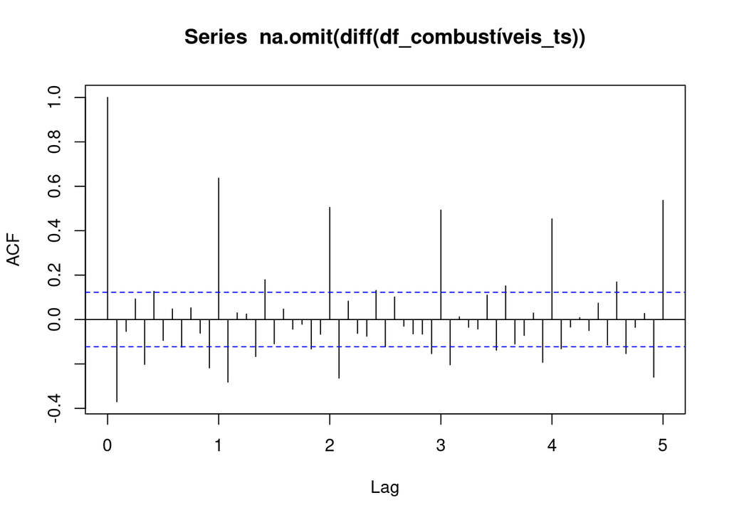

```r
acf(na.omit(diff(df_combustíveis_ts)), lag.max =60)
```

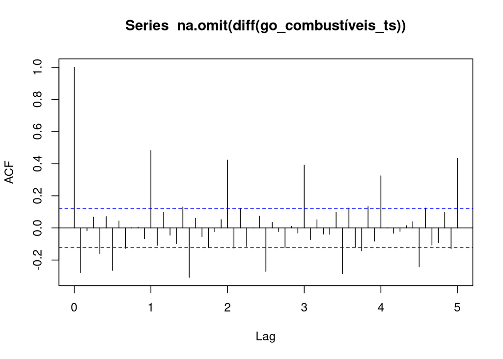

```r
acf(na.omit(diff(go_combustíveis_ts)), lag.max =60)
```

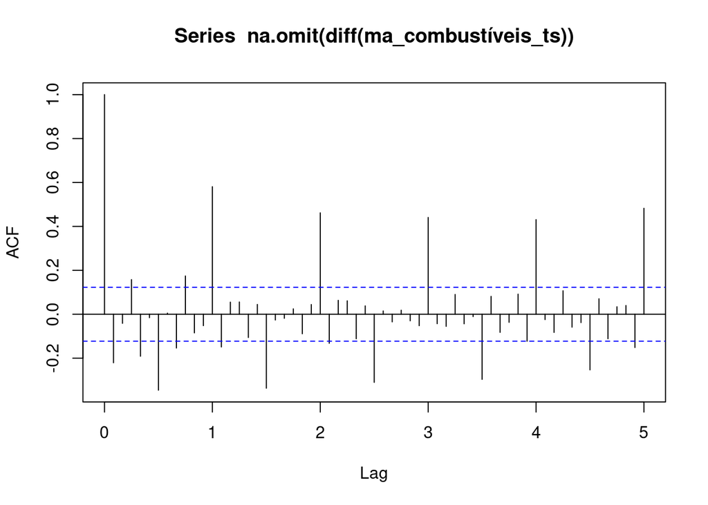

```r
acf(na.omit(diff(ma_combustíveis_ts)), lag.max =60)
```

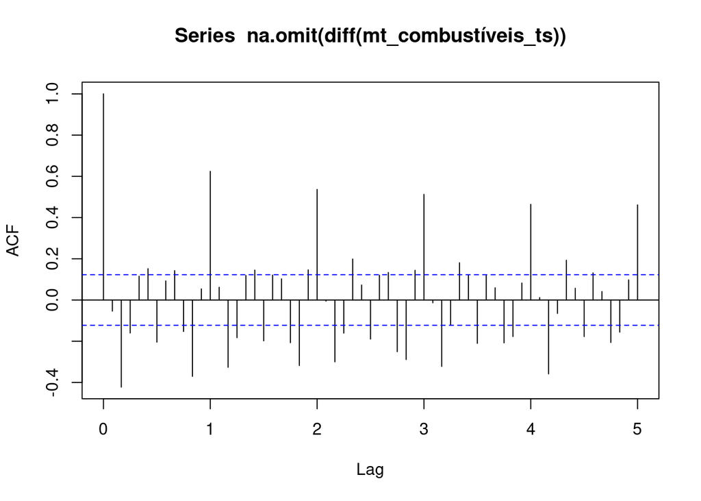

```r
acf(na.omit(diff(mt_combustíveis_ts)), lag.max =60)
```

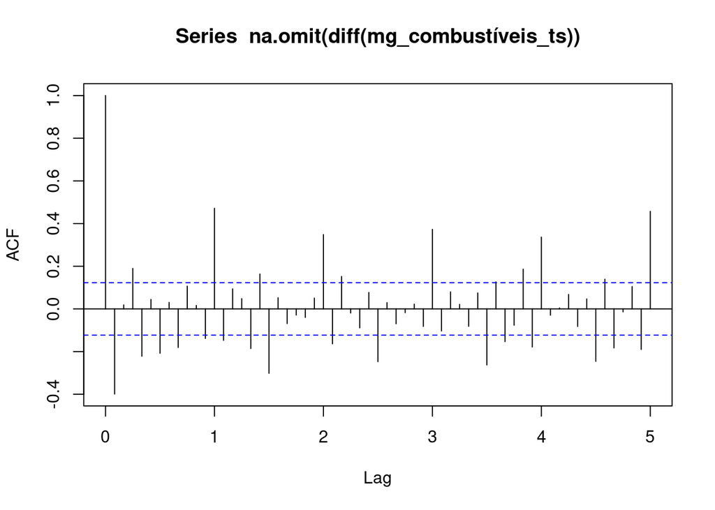

```r
acf(na.omit(diff(mg_combustíveis_ts)), lag.max =60)
```

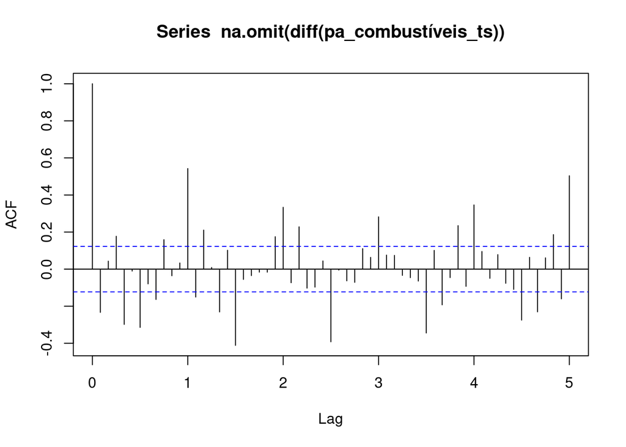

```r
acf(na.omit(diff(pa_combustíveis_ts)), lag.max =60)
```

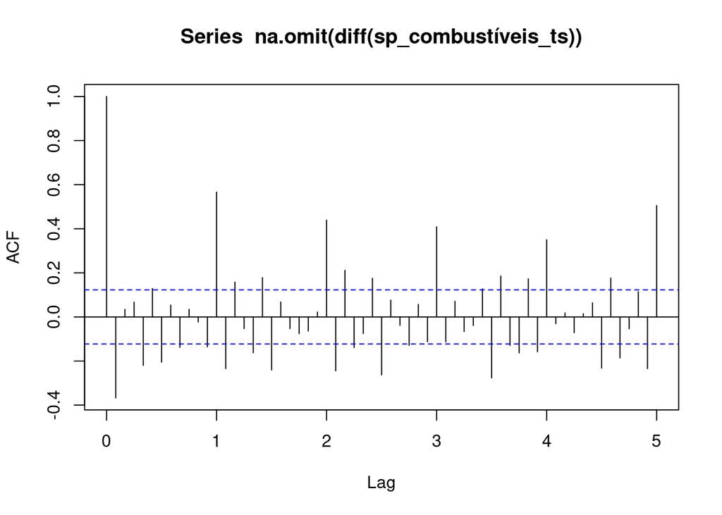

```r
acf(na.omit(diff(sp_combustíveis_ts)), lag.max =60)
```

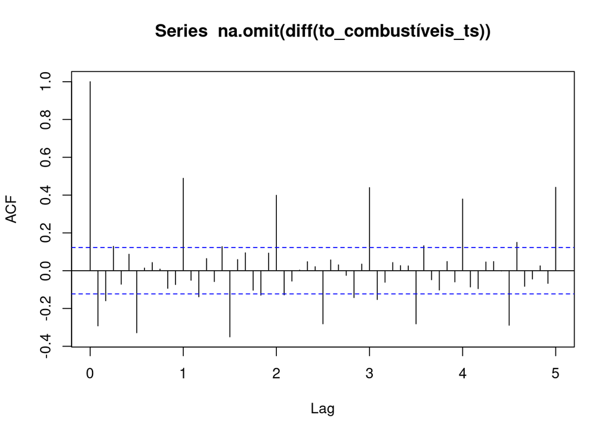

```r
acf(na.omit(diff(to_combustíveis_ts)), lag.max =60)
```

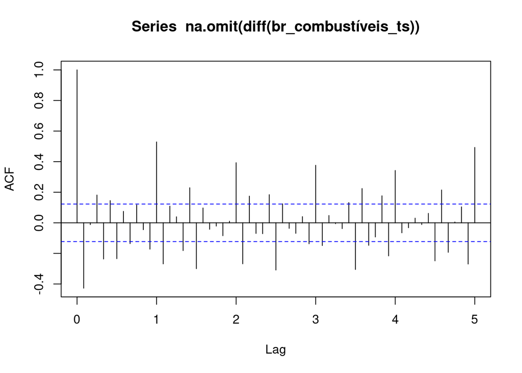

```r
acf(na.omit(diff(br_combustíveis_ts)), lag.max =60)
```

Fica evidente que, em todas as séries, a autocorrelação dispara após 12 defasagens - isto é, um ano - e também pode ficar minimamente significante nas defasagens adjacentes. Fenômeno similar, mas de magnitude menor e sinal trocado, ocorre nas defasagens referentes à metade do ano. O gráfico da FAC referente à série do Mato Grosso apresenta uma maior quantidade de defasagens significantes, provavelmente deivdo à presença de tendência determinística. Contudo, não se julgou necessário fazer o *detrending* da série, pois ainda é possível observar a sazonalidade. Em suma, a sazonalidade é semestral, sendo mais acentuada anualmente (ou seja, de 2 em 2 semestres).

### Consumo de combustível por estado

Para analisar a distribuição do consumo de cada combustível entre os estados brasileiros, serão apresentados gráficos que mostram as séries de cada estado por combustível conjuntamente e sua evolução no tempo. Um mapa também seria uma forma interessante de mostrar esse tipo de informação, mas como há dados para poucos estados, julgou-se que gráficos de linha seriam mais simples e diretos.

#### Diesel

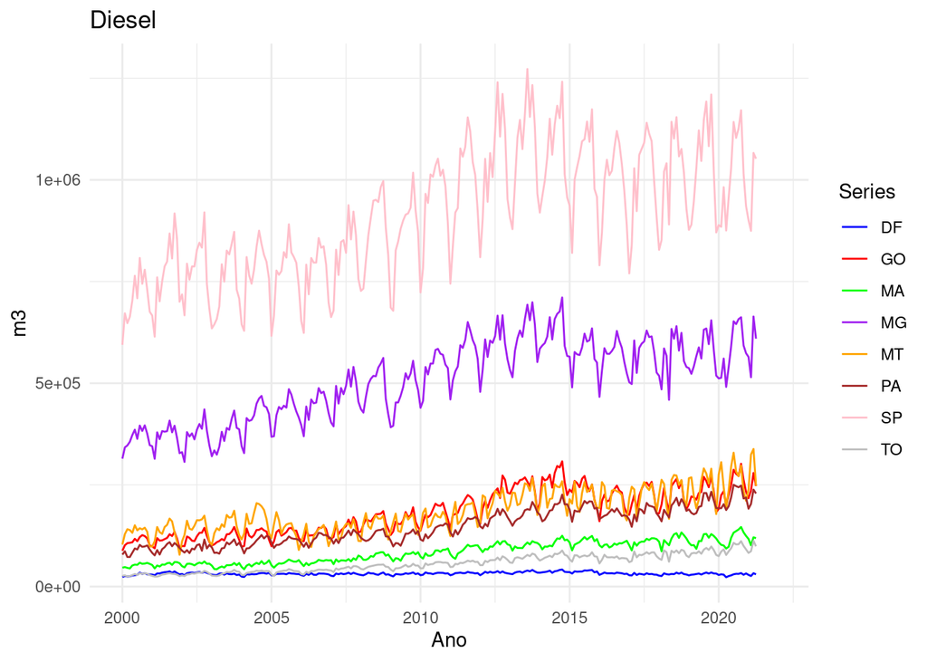

```r
ggplot() +
  geom_line(aes(x = time(df_diesel_ts), y = as.numeric(df_diesel_ts), color = "DF")) +
  geom_line(aes(x = time(go_diesel_ts), y = as.numeric(go_diesel_ts), color = "GO")) +
  geom_line(aes(x = time(ma_diesel_ts), y = as.numeric(ma_diesel_ts), color = "MA")) +
  geom_line(aes(x = time(mg_diesel_ts), y = as.numeric(mg_diesel_ts), color = "MG")) +
  geom_line(aes(x = time(mt_diesel_ts), y = as.numeric(mt_diesel_ts), color = "MT")) +
  geom_line(aes(x = time(pa_diesel_ts), y = as.numeric(pa_diesel_ts), color = "PA")) +
  geom_line(aes(x = time(sp_diesel_ts), y = as.numeric(sp_diesel_ts), color = "SP")) +
  geom_line(aes(x = time(to_diesel_ts), y = as.numeric(to_diesel_ts), color = "TO")) +
  labs(title = "Diesel",
       x = "Ano",
       y = "m3",
       color = "Series") +
  scale_color_manual(values = c("DF" = "blue", "GO" = "red", "MA" = "green",
                                "MG" = "purple", "MT" = "orange", "PA" = "brown",
                                "SP" = "pink", "TO" = "gray")) +
  theme_minimal()
```

Dentre os estados analisados, o estado com maior consumidor de diesel em qualquer período é São Paulo, seguido de Minas Gerais em um patamar inferior. Abaixo de Minas, encontram-se Mato Grosso, Pará e Goiás, sendo que qual deles consome mais varia com o tempo, mas todos o fazem na mesma ordem de grandeza. Em seguida, aparecem, em ordem decrescente de quantidade consumida, Maranhão, Tocantins e o Distrito Federal, sendo que o último consome muito pouco diesel comparado aos demais.

#### Etanol

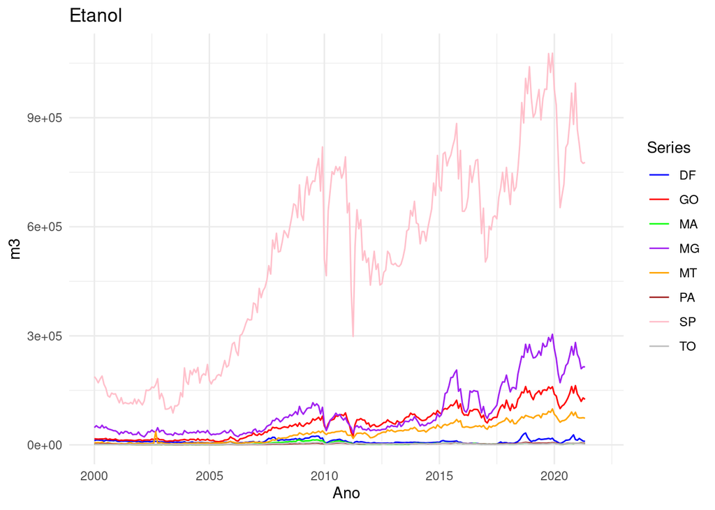

```r
ggplot() +
  geom_line(aes(x = time(df_etanol_ts), y = as.numeric(df_etanol_ts), color = "DF")) +
  geom_line(aes(x = time(go_etanol_ts), y = as.numeric(go_etanol_ts), color = "GO")) +
  geom_line(aes(x = time(ma_etanol_ts), y = as.numeric(ma_etanol_ts), color = "MA")) +
  geom_line(aes(x = time(mg_etanol_ts), y = as.numeric(mg_etanol_ts), color = "MG")) +
  geom_line(aes(x = time(mt_etanol_ts), y = as.numeric(mt_etanol_ts), color = "MT")) +
  geom_line(aes(x = time(pa_etanol_ts), y = as.numeric(pa_etanol_ts), color = "PA")) +
  geom_line(aes(x = time(sp_etanol_ts), y = as.numeric(sp_etanol_ts), color = "SP")) +
  geom_line(aes(x = time(to_etanol_ts), y = as.numeric(to_etanol_ts), color = "TO")) +
  labs(title = "Etanol",
       x = "Ano",
       y = "m3",
       color = "Series") +
  scale_color_manual(values = c("DF" = "blue", "GO" = "red", "MA" = "green",
                                "MG" = "purple", "MT" = "orange", "PA" = "brown",
                                "SP" = "pink", "TO" = "gray")) +
  theme_minimal()
```

O consumo de etanol é consideravelmente menor que o dos demais combustíveis nos primeiros períodos analisados. A partir de 2005, a série de São Paulo, que sempre é o maior consumidor, aumenta consideravelmente se distanciando das demais. As séries de Minas Gerais, de Goiás e do Mato Grosso também apresentam crescimento, porém mais recente e menos acentuado, de maneira que são, nos dados mais recentes, o segundo, terceiro e quarto maior consumidores de etanol, respectivamente. Os demais estados apresentam um nível de consumo de etanol pouco relevante quando comparados aos quatro já mencionados.

#### Gasolina

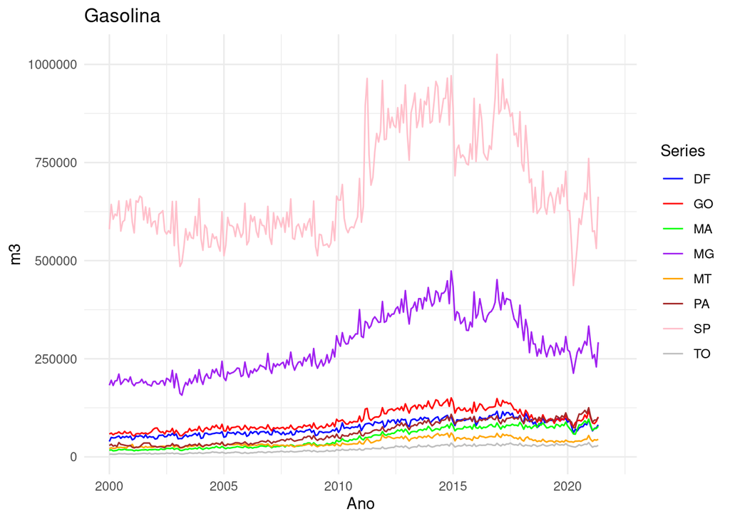

```r
ggplot() +
  geom_line(aes(x = time(df_gasolina_ts), y = as.numeric(df_gasolina_ts), color = "DF")) +
  geom_line(aes(x = time(go_gasolina_ts), y = as.numeric(go_gasolina_ts), color = "GO")) +
  geom_line(aes(x = time(ma_gasolina_ts), y = as.numeric(ma_gasolina_ts), color = "MA")) +
  geom_line(aes(x = time(mg_gasolina_ts), y = as.numeric(mg_gasolina_ts), color = "MG")) +
  geom_line(aes(x = time(mt_gasolina_ts), y = as.numeric(mt_gasolina_ts), color = "MT")) +
  geom_line(aes(x = time(pa_gasolina_ts), y = as.numeric(pa_gasolina_ts), color = "PA")) +
  geom_line(aes(x = time(sp_gasolina_ts), y = as.numeric(sp_gasolina_ts), color = "SP")) +
  geom_line(aes(x = time(to_gasolina_ts), y = as.numeric(to_gasolina_ts), color = "TO")) +
  labs(title = "Gasolina",
       x = "Ano",
       y = "m3",
       color = "Series") +
  scale_color_manual(values = c("DF" = "blue", "GO" = "red", "MA" = "green",
                                "MG" = "purple", "MT" = "orange", "PA" = "brown",
                                "SP" = "pink", "TO" = "gray")) +
  theme_minimal()
```

No caso da gasolina, São Paulo também é o maior consumidor histórico, seguido de Minas Gerais, em um nível consistentemente mais baixo. Os estados restantes apresentam um nível similar de consumo de gasolina, significativamente inferior ao de Minas e São Paulo. Em alguns anos, Goiás e DF se sobressaem ligeiramente, mas em tempos recentes se encontram juntos dos outros, com exceção do Mato Grosso e do Tocantins que estão em um patamar ainda mais baixo

### Tamanho total do mercado

Para a análise do total do mercado, foram considerados os dados do Brasil como um todo. Algumas estatísticas descritivas ajudam a ter uma noção geral a respeito do tamanho desse mercado.

```r
min(na.omit(br_combustíveis_ts))
```

```
## [1] 4556363
```

```r
max(na.omit(br_combustíveis_ts))
```

```
## [1] 10941679
```

```r
mean(na.omit(br_combustíveis_ts))
```

```
## [1] 7612198
```

Nota-se que o tamanho do mercado variou bastante, tendo como consumo mínimo de combustíveis 4556363 m³ e máximo de 10941679 m³. A média do período analisado foi de 7612198 m³. A evolução desse mercado nos últimos 5 anos pode ser vista no gráfico a seguir, que recortou esse período para maior precisão:

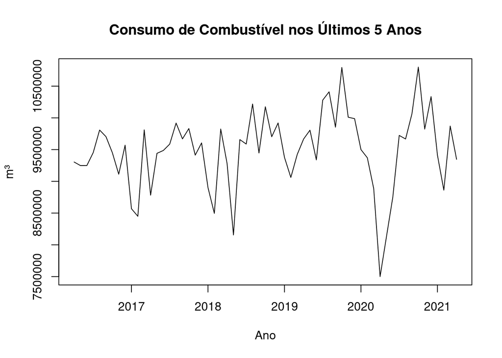

```r
subset_ts <- window(br_combustíveis_ts, start=c(2016, 4), end=c(2021, 4))

plot(subset_ts, main="Consumo de Combustível nos Últimos 5 Anos",
     ylab="m³", xlab="Ano")
```